# Examples and Quickstart

## The first step is to initilize the pendulum class

```python
pendulum = Pendulum(
            pendulum_arm_length=10.0,
            starting_angle_radians=np.pi / 4,
            acceleration_due_to_gravity=9.8,
            noise_std_percent={
                "pendulum_arm_length": 0.0,
                "starting_angle_radians": 0.1,
                "acceleration_due_to_gravity": 0.1,
            },
        )
```

## Generate positions

Next, create an array of times and use the 'create_object' to draw the position at all these points in time. The noiseless parameter determines whether noise is added to the positions in time.

```python
time = np.array(np.linspace(0, 50, 200))
pendulum_noisy = pendulum.create_object(time, noiseless=False)
pendulum_noiseless = pendulum.create_object(time, noiseless=True)
```

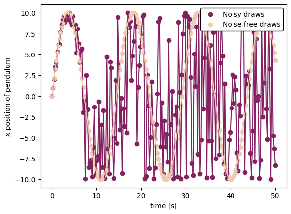

```python
plt.clf()
plt.plot(time, pendulum_noisy, color = '#832161')
plt.scatter(time, pendulum_noisy, label = 'Noisy draws', color = '#832161')
plt.plot(time, pendulum_noiseless, color = '#EDCBB1')
plt.scatter(time, pendulum_noiseless, label = 'Noise free draws', color = '#EDCBB1')
legend = plt.legend(loc="upper right", edgecolor="black")
legend.get_frame().set_alpha(1.0)
plt.xlabel('time [s]')
plt.ylabel('x position of pendulum')
plt.show()
```

# Hamiltonian Pendulum

The Hamiltonian pendulum object is one of the physics objects. This notebook runs through a couple of examples in initilizing the pendulum class and plotting the result.

```python
import numpy as np
import matplotlib.pyplot as plt
import sys, os

MAIN_DIR = os.path.dirname(os.path.abspath(''))
sys.path.insert(0, f'{MAIN_DIR}')

from deepbench.physics_object.hamiltonian_pendulum import HamiltonianPendulum
```

## The first step is to initilize the pendulum class

Inputs include the arm length, the starting angle, and the acceleration due to gravity. The pendulum class also requires 'noise_std_percent', which is a dictionary with the percent error for each parameter.

```python
pendulum = HamiltonianPendulum(
            pendulum_arm_length=10.0,
            starting_angle_radians=np.pi / 4,
            acceleration_due_to_gravity=9.8,
            noise_std_percent={
                "pendulum_arm_length": 0.0,
                "starting_angle_radians": 0.0,
                "acceleration_due_to_gravity": 0.0,
            },
        )
```

## Draw Diagrams

Next, create an array of times and use the 'create_object' returning an array containing q, p, dq/dt, dp/dt, and time steps respectively. Observe the phase space and position and time plots.

```python
time = np.array(np.linspace(0, 50, 200))
pendulum_data = pendulum.create_object(time)
```

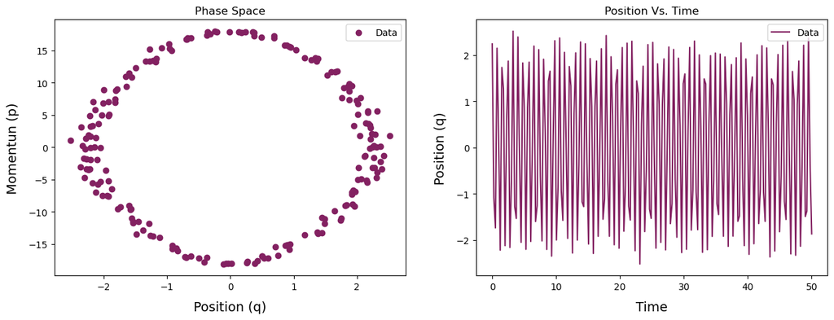

```python
fig = plt.figure(figsize=(15, 5), facecolor='white')
ax = fig.add_subplot(1,2,1)
plt.scatter(pendulum_data[0], pendulum_data[1], label='Data', color = '#832161')
plt.xlabel("Position (q)", fontsize=14, labelpad=10)
plt.ylabel("Momentun (p)", fontsize=14, labelpad=10)
plt.title("Phase Space")
plt.legend(loc='upper right')

ax = fig.add_subplot(1,2,2)
plt.plot(pendulum_data[4], pendulum_data[0], label='Data', color = '#832161')
plt.ylabel("Position (q)", fontsize=14, labelpad=10)
plt.xlabel("Time", fontsize=14, labelpad=10)
plt.title("Position Vs. Time")
plt.legend(loc='upper right')

plt.show()
```

## Shape Objects

# Create a single image with shapes

The shape module contain a number of geometric shapes. In this notebook, we will go over creating a instance of `Shapes` and how to generate shapes with and without noise, and display the results.

```python
import matplotlib.pyplot as plt

from deepbench.shapes import Shapes
from deepbench.image import ShapeImage
from deepbench.collection import Collection
```

# Noiseless Image

The first example shows how to create multiple objects without noise added to the image. We'll look at a couple of different objects and their parameters.

```python
shapes = Shapes(image_shape=(28,28)) # Make an instance of the Shapes class
```

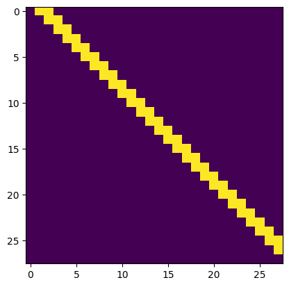

```python
line = shapes.create_line() # Create a line using the random defaults

plt.imshow(line)
plt.show()
```

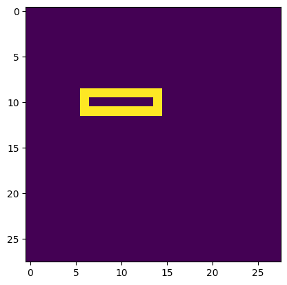

```python
# Create a rectangle specifying the specific center and width/length

rectange = shapes.create_rectangle(
    center=(10,10),
    width=2,
    height=8)

plt.imshow(rectange)
plt.show()
```

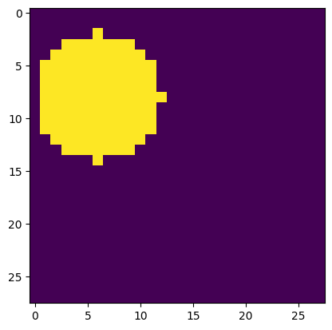

```python
# Create a filled-in circle
circle = shapes.create_ellipse(center=(8, 6), width=12, height=12, fill=True)
plt.imshow(circle)
plt.show()
```

# Noisy Image

Now, we'll add noise to all those images using the `ShapeImage` class. The `ShapeImage` both combines shapes and adds noise to the image. You can make either single shape images, or add many together.

```python
shape_image = ShapeImage(
    image_shape=(28,28),
    object_noise_level=0.2
    ) # Add .2 sigma of guassian noise
```

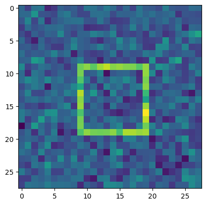

```python
# A single rectangle in a noisy image
noisy_rectangle = shape_image.combine_objects(
    objects=["rectangle"],
    instance_params={},
    object_params={} # Using all the default values
)
plt.imshow(noisy_rectangle)
```

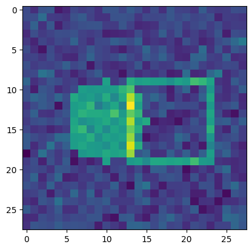

```python
# An image with both noise and multiple shapes

noisy_rectange = shape_image.combine_objects(
    objects=["ellipse", "rectangle"],
    instance_params=[{},{}],
    object_params=[
        {"center":(14,10), "fill":True}, # The circle parameters
        {"center":(14,18)} # The rectangle parameters
    ]
)
plt.imshow(noisy_rectange)
```

## Using a collection

If you want to do this same thing, but keep track of the parameters and the default values, we recommend you use a `Collection`.

This has a similar interface to the `Image` type objects, but work through initializing the `Collection` with the full parameters of your dataset.

```python
import numpy as np


shape_config = {
    "object_type": "shape", # Defines that this is a shape module
    "object_name": "ShapeImage", # Class used to generate the image

    "total_runs": 1,
    "image_parameters": {
        "image_shape": (28, 28),
        "object_noise_level": 0.2 # Collection noise level
    },
    "object_parameters": {
        "rectangle": { # First object in the image
            "object": {
                "width": np.random.default_rng().integers(2, 28),
                "height": np.random.default_rng().integers(2, 28),
                "fill": True
                       },
            "instance": {}
        },
        "arc":{ # Second object in the image
            "object": {
                "radius": np.random.default_rng().integers(2, 6),
                "theta1":np.random.default_rng().integers(0, 20),
                "theta2":np.random.default_rng().integers(60, 180)
            },
            "instance":{}
        }}
    }
```

```python
shape_collection = Collection(object_config=shape_config) # initalize
shape_collection() # generate the images
```

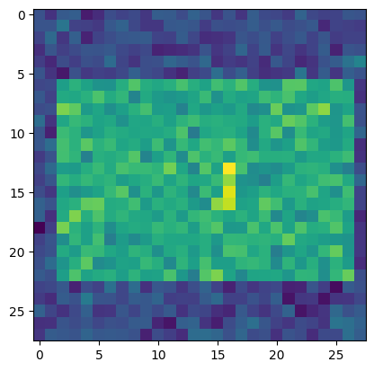

```python
plt.imshow(shape_collection.objects[0]) # First and only image in the collection
plt.show()
```

```python
shape_collection.object_params[0]
```

```
{'object_noise_type': 'gaussian',
 'object_noise_level': 0.2,
 'seed': 241557,
 'rectangle': {'object': {'width': 16, 'height': 24, 'fill': True},
  'instance': {}},
 'arc': {'object': {'radius': 3, 'theta1': 5, 'theta2': 129}, 'instance': {}},
 'image_shape': (28, 28)}
```